# Homework 3

Mark Wilber

2024-10-09

# The effect of environmental variability on the reproductive phenology of Antarctic birds

## Background

In this analysis, you are going to focus on two Antarctic bird species: the Adelie Penguin (*Pygoscelis adeliae*) and the Cape Petrel (*Daption capense*). You are interested in how environmental variability (e.g., directional variability like climate change and cyclic variability like El Nino) affects the egg laying dates of these two bird species.

The Adelie Penguin is a medium-sized penguin (c. 4.5 kg), breeding during the austral summer on rocky islands or on coastal nunataks (ice-free areas of the Antarctic continent). Adelies arrive and start building their nest in October and lay their eggs in November. The chicks leave the colonies in early February, just before the winter.

The Cape Petrel is a small (c. 400 g) Procellariiform species and breeds during the austral summer on rocky islands. The breeding period is relatively short because birds arrive in October, lay their eggs in November, and the chicks are fledged in early March.

During the breeding period, the two species feed directly on krill or on fish that heavily depend on krill. Krill abundance and distribution are closely related to sea ice. After winters with extensive sea ice, adult krill survival and krill recruitment are high; therefore, krill abundance is higher after winters with extensive sea ice compared to winters with poor sea ice. Thus, you expect that sea ice extent might affect food resources for these birds.

Moreover, other climatic factors such as El Nino and La Nina cycles can affect and nutrient upwelling in Antarctica and can influence krill abundance and the general fitness of the birds, affecting reproduction.

The data set contains the following variables

- `Year`: The year that a data point was collected
- `MSA`: Methanesulphonic acid concentration. A measure of biological activity in the surface of ocean water that is a strong proxy for sea ice extent (high MSA in a given year means high sea ice extent that year). Used to infer sea ice extent when satellite coverage wasn’t available.
- `SOI`: Southern oscillation index. High, positive values of SOI indicate La Nina conditions and low negative values indicate El Nino conditions.
- `species`: A factor with two levels: AdeliePenguin or CapePetrel
- `laying_date`: The average day of year where birds within a colony laid eggs

Your goal is to make causal inference on the effects of environmental variability on laying date for each species.

## Question 1

Draw a DAG that you think biologically and causally describes the relationship between the variables in the dataset.

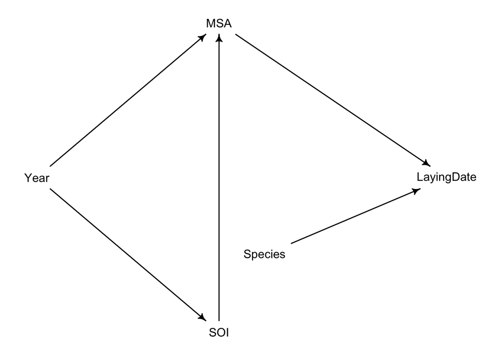

```r
library(dagitty) # Package for building DAGs

# Build your DAG
#
#SOI -> LayingDate
dag2 <- dagitty("dag{
Species -> LayingDate
SOI -> MSA
MSA -> LayingDate
Year -> SOI
Year -> MSA
}")

# Format your DAG
#coordinates(dag2) <- list(x=c(Year=1, Species=5, SOI=5,
#                             MSA = 5, LayingDate=10),
#                         y=c(Year=5, Species=5, SOI=9,
#                           MSA = 1, LayingDate=5))

coordinates(dag2) <- list(x=c(Year=1, Species=6, SOI=5,
                              MSA = 5, LayingDate=10),
                         y=c(Year=5, Species=7, SOI=9,
                            MSA = 1, LayingDate=5))
# Visualize DAG
rethinking::drawdag(dag2)
```

```r
# Look at implied dependencies
impliedConditionalIndependencies(dag2)
```

```
## LynD _||_ SOI | MSA
## LynD _||_ Year | MSA
## MSA _||_ Spcs
## SOI _||_ Spcs
## Spcs _||_ Year
```

## Question 2

```r
# Reading in the dataset
library(GGally)
bird_data = read.csv("bird_data.csv")
bird_data
```

```
##    Year   MSA    SOI       species laying_date
## 1  1953 0.101  -2.28 AdeliePenguin         245
## 2  1957 0.072  10.73 AdeliePenguin         248
## 3  1959 0.078  -3.20 AdeliePenguin         242
## 4  1962 0.086   0.80 AdeliePenguin         244
## 5  1963 0.137   5.40 AdeliePenguin         243
## 6  1964 0.098  -1.95 AdeliePenguin         242
## 7  1965 0.111   6.28 AdeliePenguin         244
## 8  1968 0.065   3.20 AdeliePenguin         243
## 9  1969 0.082   3.02 AdeliePenguin         244
## 10 1972 0.064  10.95 AdeliePenguin         245
## 11 1973 0.071  -7.35 AdeliePenguin         245
## 12 1974 0.063   7.28 AdeliePenguin         243
## 13 1975 0.106   9.90 AdeliePenguin         246
## 14 1976 0.087  13.60 AdeliePenguin         242
```

[output cut: 42 more lines]

```r
head(bird_data)
```

```
##   Year   MSA   SOI       species laying_date
## 1 1953 0.101 -2.28 AdeliePenguin         245
## 2 1957 0.072 10.73 AdeliePenguin         248
## 3 1959 0.078 -3.20 AdeliePenguin         242
## 4 1962 0.086  0.80 AdeliePenguin         244
## 5 1963 0.137  5.40 AdeliePenguin         243
## 6 1964 0.098 -1.95 AdeliePenguin         242
```

```r
#ggpairs(bird_data)
```

Using your DAG, fit Bayesian linear models to answer the following questions. You don’t necessarily have to fit a linear model for each question. You may be able to fit one linear model that answers multiple questions. **Hint**: I think you can answer all of these questions with two linear models.

1. Do average laying dates differ between Adelie Penguins and Cape Petrels?
2. Every year, are the laying dates increasing, decreasing, or staying the same? By how much (in units of days)?
3. What is the effect of sea ice extent (using MSA as a proxy) on Adelie Penguin’s and Cape Petrel’s laying date (assume the effect is the same for both species)?
4. What is the effect of the SOI on laying date?

I am purposefully not specifying every component you need in the analyses. Based on what we have learned in class, provide what you think is reasonable information to support your **Bayesian-informed** answers to these questions.

```r
 ## 1 ##
# ??? I didn't fit a model for this idk how

# Average laying dates of Adelie Penguins and Cape Petrels

penguins <- subset(bird_data, species == "AdeliePenguin")
#penguins
peng_mean <- mean(penguins$laying_date, na.rm = TRUE)
peng_mean
```

```
## [1] 245.5152
```

```r
petrels <- subset(bird_data, species == "CapePetrel")
#petrels
petr_mean <- mean(petrels$laying_date, na.rm = TRUE)
petr_mean
```

```
## [1] 262.8261
```

```r
# Difference between the means of the species laying dates

diff_lay_date = petr_mean - peng_mean
diff_lay_date # There is a 17.31094 day difference between the species laying dates. The Cape Petrels lay date is later than the Adelie Penguin.
```

```
## [1] 17.31094
```

```r
 ## 2 ##
```

```r
# Quick way to standardize your dataset
penguins$species <- NULL #drop the species column since this dataframe only contains penguin info
penguins
```

```
##    Year   MSA    SOI laying_date
## 1  1953 0.101  -2.28         245
## 2  1957 0.072  10.73         248
## 3  1959 0.078  -3.20         242
## 4  1962 0.086   0.80         244
## 5  1963 0.137   5.40         243
## 6  1964 0.098  -1.95         242
## 7  1965 0.111   6.28         244
## 8  1968 0.065   3.20         243
## 9  1969 0.082   3.02         244
## 10 1972 0.064  10.95         245
## 11 1973 0.071  -7.35         245
## 12 1974 0.063   7.28         243
## 13 1975 0.106   9.90         246
## 14 1976 0.087  13.60         242
```

[output cut: 19 more lines]

```r
peng_data_z = as.data.frame(scale(penguins))
peng_data_z
```

```
##           Year         MSA         SOI laying_date
## 1  -2.08614886  1.24168685 -0.24677282  -0.2331366
## 2  -1.75317226 -0.03467654  1.52491575   1.1245413
## 3  -1.58668396  0.22939864 -0.37205749  -1.5908145
## 4  -1.33695150  0.58149889  0.17265844  -0.6856959
## 5  -1.25370735  2.82613796  0.79908177  -1.1382552
## 6  -1.17046320  1.10964926 -0.20183376  -1.5908145
## 7  -1.08721905  1.68181216  0.91891928  -0.6856959
## 8  -0.83748660 -0.34276425  0.49948801  -1.1382552
## 9  -0.75424245  0.40544877  0.47497579  -0.6856959
## 10 -0.50451000 -0.38677678  1.55487513  -0.2331366
## 11 -0.42126585 -0.07868907 -0.93720027  -0.2331366
## 12 -0.33802170 -0.43078932  1.05509826  -1.1382552
## 13 -0.25477755  1.46174950  1.41188720   0.2194227
## 14 -0.17153340  0.62551142  1.91574944  -1.5908145
```

[output cut: 19 more lines]

```r
petrels$species <- NULL #drop the species column since this dataframe only contains petrels info
petrels
```

```
##    Year   MSA    SOI laying_date
## 34 1953 0.101  -2.28         260
## 35 1957 0.072  10.73         259
## 36 1963 0.137   5.40         261
## 37 1965 0.111   6.28         262
## 38 1968 0.065   3.20         260
## 39 1972 0.064  10.95         261
## 40 1973 0.071  -7.35         268
## 41 1975 0.106   9.90         259
## 42 1976 0.087  13.60         262
## 43 1977 0.078   1.11         266
## 44 1978 0.064  -9.90         265
## 45 1979 0.080  -1.65         265
## 46 1983 0.090 -13.05         264
## 47 1985 0.082  -0.11         260
## 48 1986 0.061   0.86         263
## 49 1987 0.096  -2.38         261
## 50 1988 0.048 -13.08         263
## 51 1990 0.034   6.77         265
## 52 1992 0.041  -8.78         264
## 53 1993 0.056 -10.38         269
## 54 1994 0.076  -9.47         262
## 55 1995 0.065 -11.93         263
## 56 1996 0.054  -2.27         263
```

```r
petr_data_z = as.data.frame(scale(petrels))
petr_data_z
```

```
##           Year         MSA        SOI laying_date
## 34 -2.13606355  1.05707555 -0.1482450 -1.05688199
## 35 -1.81177667 -0.15023505  1.4022391 -1.43085562
## 36 -1.32534636  2.55580596  0.7670292 -0.68290836
## 37 -1.16320292  1.47338956  0.8719044 -0.30893474
## 38 -0.91998777 -0.44165486  0.5048413 -1.05688199
## 39 -0.59570089 -0.48328626  1.4284579 -0.68290836
## 40 -0.51462917 -0.19186645 -0.7524690  1.93490703
## 41 -0.35248573  1.26523256  1.3033227 -1.43085562
## 42 -0.27141402  0.47423595  1.7442752 -0.30893474
## 43 -0.19034230  0.09955335  0.2557628  1.18695977
## 44 -0.10927058 -0.48328626 -1.0563686  0.81298615
## 45 -0.02819886  0.18281615 -0.0731639  0.81298615
## 46  0.29608802  0.59913015 -1.4317741  0.43901252
## 47  0.45823145  0.26607895  0.1103676 -1.05688199
## 48  0.53930317 -0.60818046  0.2259687  0.06503889
## 49  0.62037489  0.84891855 -0.1601626 -0.68290836
## 50  0.70144661 -1.14938866 -1.4353494  0.06503889
## 51  0.86359005 -1.73222826  0.9303008  0.81298615
## 52  1.02573349 -1.44080846 -0.9228911  0.43901252
## 53  1.10680520 -0.81633746 -1.1135733  2.30888066
## 54  1.18787692  0.01629055 -1.0051228 -0.30893474
## 55  1.26894864 -0.44165486 -1.2982966  0.06503889
## 56  1.35002036 -0.89960026 -0.1470532  0.06503889
```

```r
# Attempting to write a model???
# ??? Species is discrete. IDK how to put that in this model
library(rethinking)
mod_penguins = quap(
            alist(
                laying_date ~ dnorm(mu, sigma),
                mu <- beta0  + betaMSA*MSA + betaSOI* SOI,
                beta0 ~ dnorm(0, 3),
                c(betas, betaMSA, betaSOI) ~ dnorm(0, 3),
                sigma ~ dexp(1)
                ), data=peng_data_z)

precis(mod_penguins, prob=0.95)
```

```
##                  mean        sd       2.5%      97.5%
## beta0    2.082697e-07 0.1541851 -0.3021971 0.30219753
## betas   -1.684698e-05 3.0000000 -5.8799088 5.87987510
## betaMSA -2.857053e-01 0.1607519 -0.6007731 0.02936259
## betaSOI -2.331964e-01 0.1607518 -0.5482642 0.08187136
## sigma    8.868983e-01 0.1070332  0.6771171 1.09667952
```

```r
mod_petrals = quap(
            alist(
                laying_date ~ dnorm(mu, sigma),
                mu <- beta0  + betaMSA*MSA + betaSOI* SOI,
                beta0 ~ dnorm(0, 3),
                c(betas, betaMSA, betaSOI) ~ dnorm(0, 3),
                sigma ~ dexp(1)
                ), data=petr_data_z)
precis(mod_petrals, prob=0.95)
```

```
##                  mean        sd       2.5%       97.5%
## beta0   -1.794214e-07 0.1619979 -0.3175103  0.31750994
## betas    1.135192e-05 3.0000000 -5.8798806  5.87990330
## betaMSA -2.973234e-01 0.1745698 -0.6394739  0.04482714
## betaSOI -4.201402e-01 0.1745700 -0.7622911 -0.07798928
## sigma    7.780500e-01 0.1119127  0.5587052  0.99739485
```

## Question 3

For each model that you fit, use mean distributions/posterior predictive distributions (**hint**: explore the function `postcheck` in `rethinking`), residual plots (plot predicted values vs. residuals), and qqplots to assess the fit of your model(s). Also check whether there are any inconsistencies between the implied dependencies of your DAG and the correlations you are seeing in your data.

Draw some conclusions on whether you think it is appropriate to draw any biological inference from these models based on whether they meet your assumptions.

## Question 4

Even if you answered no to the above question, for the sake of this homework, interpret your results biologically. What do you conclude about the effects of environmental variability on the reproductive phenology of the two Antarctic bird species?